# Finding initial values

Here’s an another attempt to find the initial values (improve `startfun`).

Given the following data, we have some information about the peak.

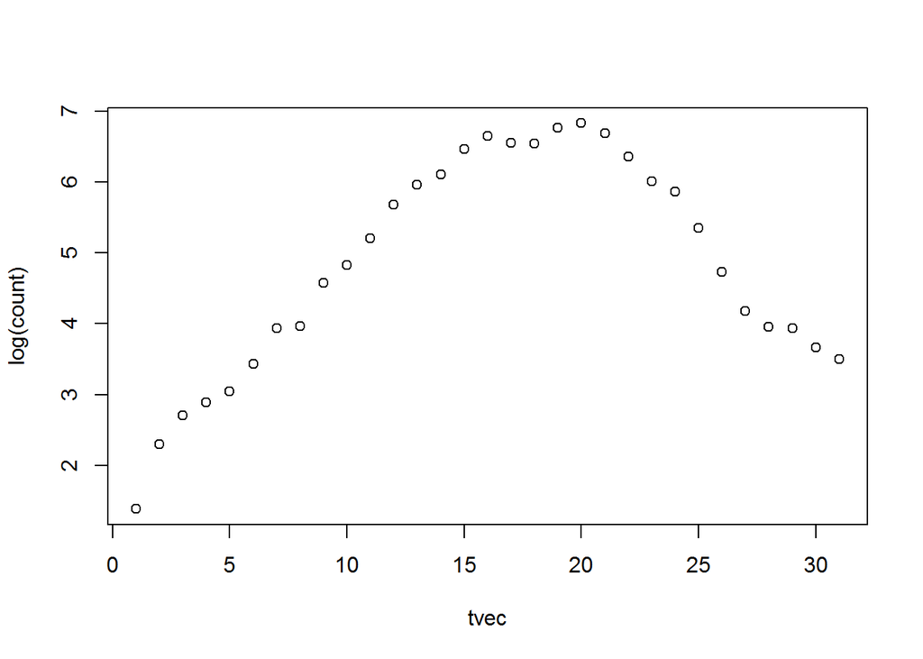

```r
plot(log(count)~tvec, data = bombay2)
```

We’re particularly interested in the following:

$$S_\textrm{peak} = \gamma N/\beta$$

We want to approximate this value using the following method. Assume that $I(t)$ continues to grow exponentially:

$$I(t) \approx I(0) \exp(rt)$$

Based on this assumption, we can do the following:

$$\begin{aligned}
\frac{dR}{dt} &\approx \gamma I(0) \exp(rt)\\
R(t) &\approx \frac{\gamma}{r} I(0) \{\exp(rt) - 1\}
\end{aligned}$$

Then, we have

$$\begin{aligned}
S_\textrm{peak} &= N - I_\textrm{peak} - R_\textrm{peak}\\
\gamma N/\beta &= N - I_\textrm{peak} - \frac{\gamma}{r} I(0) \{\exp(rt_\textrm{peak}) - 1\}
\end{aligned}$$

Finally, we combine this with remaining equations:

$$\begin{cases}
I(0) = N i_0\\
r = \beta - \gamma\\
-Q/I_\textrm{peak} = \beta \gamma/N\\
\gamma N/\beta = N - I_\textrm{peak} - \frac{\gamma}{r} I(0) \{\exp(rt_\textrm{peak}) - 1\}
\end{cases}$$

Let’s solve this. For now we’re going to denote $d_0 = I(0) (\exp(r' t_\textrm{peak}) -1)/r'$ so that it’s easier to read. Then, we have

$$\begin{cases}
a_0 = N i_0\\
b_0 = \beta - \gamma\\
c_0 = \beta \gamma/N\\
\gamma N/\beta = N - I_\textrm{peak} - d_0 \gamma
\end{cases}$$

Solving this equation, we actually get a really nice solution:

$$\begin{cases}
\gamma = \frac{c_0 I_{peak}}{b_0 - c_0 d_0}\\
\beta = b_0 + \gamma\\
N = \beta \gamma/c_0\\
i_0 = a_0/N
\end{cases}$$

Let’s try out three different ways to approximate $R_\textrm{peak}$:

Here’s the function:

```r
getGamma <- function(r, tmax){
    x <- list()
    ## everything else defined in the global environment
    d0 <- a0 * (exp(r * tmax) - 1)/r

    gamma <- c0 * Ip/(b0 - c0 * d0)
    beta <- b0 + gamma
    N <- beta * gamma/c0
    i0 <- a0/N
    c(log.beta = log(beta),
      log.gamma = log(gamma),
      log.N = log(N),
      logit.i = qlogis(i0))
}
```

## Under approximation

Assuming $I(0) \exp(rt) = I_\textrm{peak}$:

```r
r_under <- log(Ip/a0)/ss.tmax
(coef1 <- getGamma(r_under, ss.tmax))
```

```
##   log.beta  log.gamma      log.N    logit.i
## -0.1188640 -0.6142004  8.7816291 -7.1655899
```

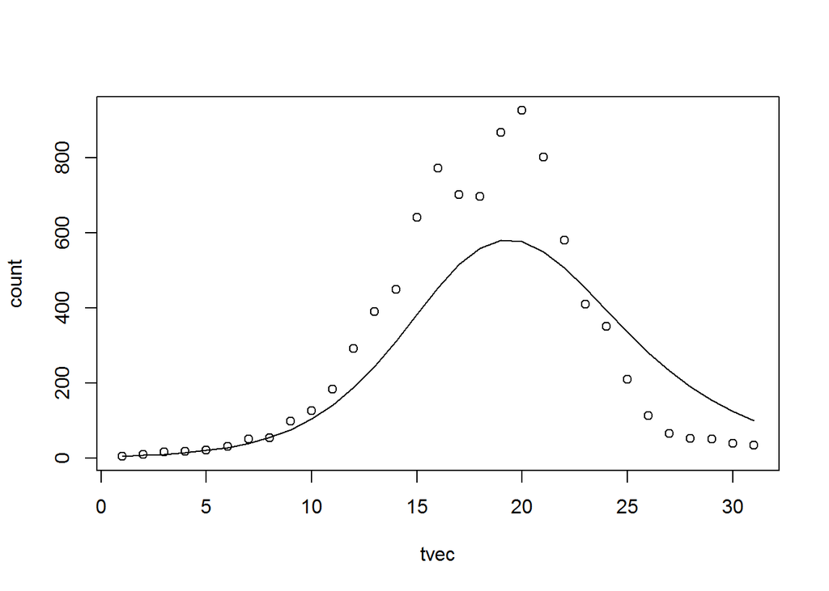

```r
plot(count~tvec, data = bombay2)
lines(tvec, SIR.detsim(tvec, trans.pars(coef1)))
```

Not bad…

## Over approximation

Assuming $r' = b_0$:

```r
(coef2 <- getGamma(b0, ss.tmax))
```

```
##  log.beta log.gamma     log.N   logit.i
## -1.603507       NaN       NaN       NaN
```

$b_0 - c_0d_0$ goes negative so this breaks… I wonder if the under approximation method can break as well…

## Average

Taking the average between the two:

```r
(coef3 <- getGamma((r_under + b0)/2, ss.tmax))
```

```
##  log.beta log.gamma     log.N   logit.i
##       NaN       NaN  8.661441 -7.045303
```

We can try taking a weighted mean… (write an algorithm for it):

```r
(coef4 <- getGamma((2 * r_under + b0)/3, ss.tmax))
```

```
##   log.beta  log.gamma      log.N    logit.i
##   3.073697   3.057525  15.645915 -14.030647
```

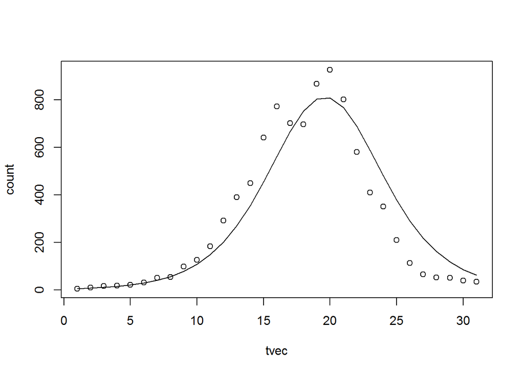

```r
plot(count~tvec, data = bombay2)
lines(tvec, SIR.detsim(tvec, trans.pars(coef4)))
```

This auto start method is able to give us really good starting value but is unstable. Also, it seems very sensitive to the estimates of second derivative at the peak and $R_\textrm{peak}$.

How can we improve this?

## Weighting algorithm

```r
weight <- function(n = 6){
    low <- log(r_under)
    high <- log(b0)

    i <- 0

    repeat{
        i <- i + 1
        log.r <- (low + high)/2
        r <- exp(log.r)
        d0 <- a0 * (exp(r * ss.tmax) - 1)/r

        if(b0 - c0 * d0 > 0){
            low <- log(r)
            if(i > n){
                break
            }
        }else{
            high <- log(r)
        }
    }
    return(r)
}

(coef5 <- getGamma(weight(), ss.tmax))
```

```
##   log.beta  log.gamma      log.N    logit.i
##   4.342578   4.338058  18.195329 -16.580062
```

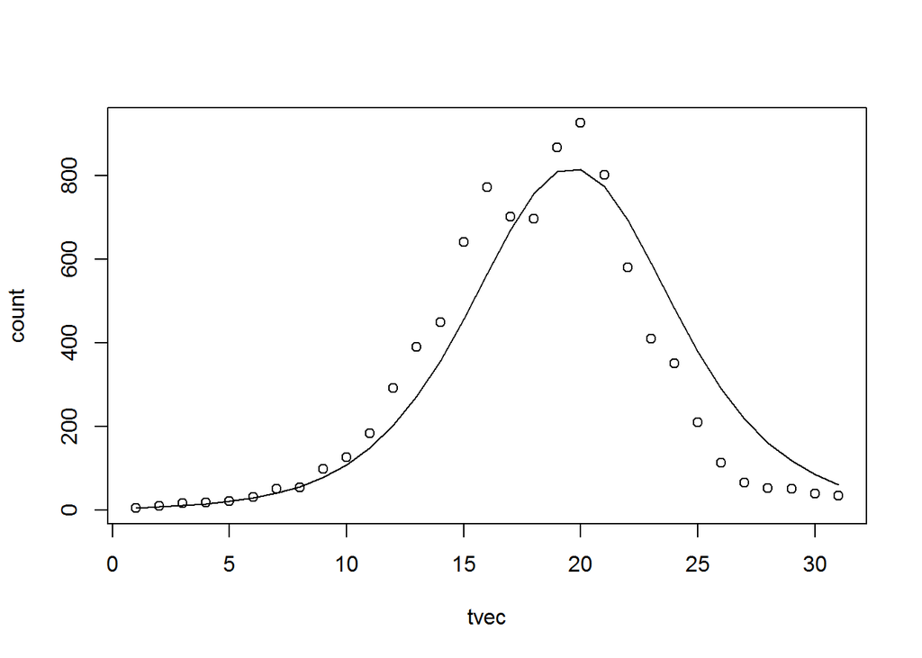

```r
plot(count~tvec, data = bombay2)
lines(tvec, SIR.detsim(tvec, trans.pars(coef5)))
```

After we repeat the algorithm certain amount of time, goodness of fit doesn’t really increase… Maybe we can add another condition so that the algorithm stops once nll starts to stay constant….?